# Airway: DE analysis

Lieven Clement

8 November 2019

# 1 Background

The data used in this workflow comes from an RNA-seq experiment where airway smooth muscle cells were treated with dexamethasone, a synthetic glucocorticoid steroid with anti-inflammatory effects (Himes et al. 2014). Glucocorticoids are used, for example, by people with asthma to reduce inflammation of the airways. In the experiment, four human airway smooth muscle cell lines were treated with 1 micromolar dexamethasone for 18 hours. For each of the four cell lines, we have a treated and an untreated sample. For more description of the experiment see the article, PubMed entry 24926665, and for raw data see the GEO entry GSE52778.

# 2 Data

FastQ files with a small subset of the reads can be found on https://github.com/statOmics/SGA2019/tree/data-rnaseq Here, we will not use our count table because it is based on a small subset of the reads. We will use the count table that was provided after mapping all the reads with the read mapper star.

```r
library(edgeR)
```

# 3 Read featurecounts object

We import the featurecounts object that we have stored.

```r
fc <- readRDS("featureCounts/star_featurecounts.rds")
colnames(fc$counts)
```

```
## [1] "SRR1039508" "SRR1039509" "SRR1039512" "SRR1039513" "SRR1039516"
## [6] "SRR1039517" "SRR1039520" "SRR1039521"
```

## 3.1 Read Meta Data

```r
target<-readRDS("airwayMetaData.rds")
```

# 4 Data Analysis

## 4.1 Setup count object edgeR

```r
dge<-DGEList(fc$counts)
colnames(dge)==target$Run
```

```
##  [1]  TRUE  TRUE FALSE FALSE FALSE FALSE FALSE FALSE FALSE FALSE FALSE FALSE
## [13] FALSE FALSE FALSE FALSE
```

```r
target$Run%in%colnames(dge)
```

```
##  [1]  TRUE  TRUE FALSE FALSE  TRUE  TRUE FALSE FALSE  TRUE  TRUE FALSE FALSE
## [13]  TRUE  TRUE FALSE FALSE
```

```r
rownames(target)<-target$Run
target<-target[colnames(dge),]
target[,grep(":ch1",colnames(target))]
```

```
##            cell line:ch1              cell type:ch1 ercc_mix:ch1
## SRR1039508        N61311 airway smooth muscle cells            -
## SRR1039509        N61311 airway smooth muscle cells            -
## SRR1039512       N052611 airway smooth muscle cells            -
## SRR1039513       N052611 airway smooth muscle cells            1
## SRR1039516       N080611 airway smooth muscle cells            -
## SRR1039517       N080611 airway smooth muscle cells            -
## SRR1039520       N061011 airway smooth muscle cells            1
## SRR1039521       N061011 airway smooth muscle cells            1
##                                  tissue:ch1 treatment:ch1
## SRR1039508 human airway smooth muscle cells     Untreated
## SRR1039509 human airway smooth muscle cells Dexamethasone
## SRR1039512 human airway smooth muscle cells     Untreated
## SRR1039513 human airway smooth muscle cells Dexamethasone
## SRR1039516 human airway smooth muscle cells     Untreated
## SRR1039517 human airway smooth muscle cells Dexamethasone
## SRR1039520 human airway smooth muscle cells     Untreated
## SRR1039521 human airway smooth muscle cells Dexamethasone
```

```r
target$cellLine<-as.factor(target[,grep("cell line:ch1",colnames(target))])
target$treatment<-as.factor(target[,grep("treatment:ch1",colnames(target))])
target$treatment<-relevel(target$treatment,"Untreated")
```

```r
colnames(dge)<-paste0(substr(target$cellLine,1,3),"_",substr(target$treatment,1,3))
```

## 4.2 Filtering and normalisation

```r
design<-model.matrix(~treatment+cellLine,data=target)
keep <- filterByExpr(dge, design)
dge <- dge[keep, ,keep.lib.sizes=FALSE]
dge<-calcNormFactors(dge)
```

## 4.3 Data exploration

One way to reduce dimensionality is the use of multidimensional scaling (MDS). For MDS, we first have to calculate all pairwise distances between our objects (samples in this case), and then create a (typically) two-dimensional representation where these pre-calculated distances are represented as accurately as possible. This means that depending on how the pairwise sample distances are defined, the two-dimensional plot can be very different, and it is important to choose a distance that is suitable for the type of data at hand.

[figure not shown]

```r
plotMDS(dge, top = 500,col=as.double(target$cellType))
```

## 4.4 Differential analysis

### 4.4.1 Model

We first estimate the overdispersion.

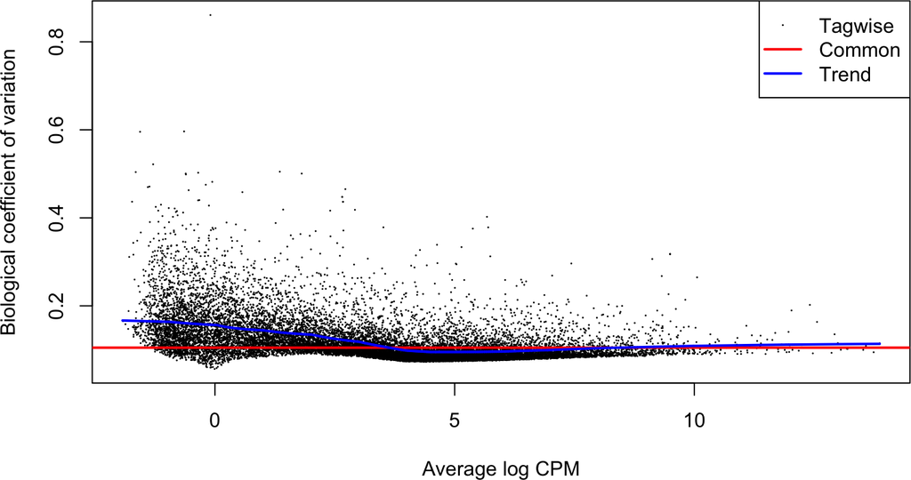

```r
dge <- estimateDisp(dge, design)
plotBCV(dge)
```

Finally, we fit the generalized linear model and perform the test. In the glmLRT function, we indicate which coefficient (which column in the design matrix) that we would like to test for. It is possible to test more general contrasts as well, and the user guide contains many examples on how to do this. The topTags function extracts the top-ranked genes. You can indicate the adjusted p-value cutoff, and/or the number of genes to keep.

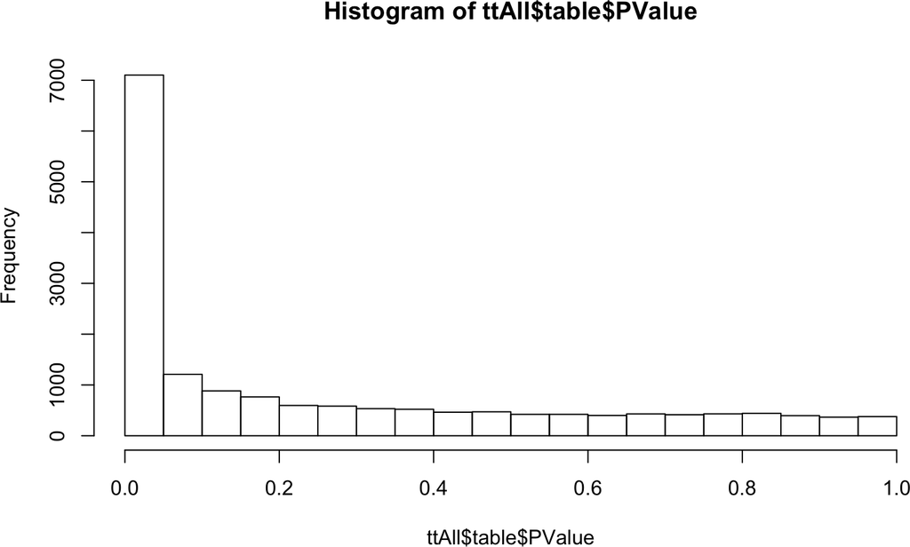

```r
fit <- glmFit(dge, design)
lrt <- glmLRT(fit, coef = "treatmentDexamethasone")
ttAll <-topTags(lrt, n = nrow(dge)) # all genes
hist(ttAll$table$PValue)
```

```r
tt <- topTags(lrt, n = nrow(dge), p.value = 0.05) # genes with adj.p<0.05
tt
```

```
## Coefficient:  treatmentDexamethasone
##                               logFC       logCPM          LR        PValue
## ENSG00000109906.13        7.1541888  4.123286129 1300.289405 9.779800e-285
## ENSG00000165995.19        3.2097008  4.653657056  854.922065 6.187321e-188
## ENSG00000152583.12        4.5678867  5.507109682  637.322423 1.277250e-140
## ENSG00000171819.4         5.6770189  3.479398820  588.500610 5.309432e-130
## ENSG00000120129.5         2.9451092  7.285300508  539.384728 2.566161e-119
## ENSG00000189221.9         3.3485630  6.743366657  518.724763 8.016547e-115
## ENSG00000162692.11       -3.6770279  4.565453572  502.440265 2.799113e-111
## ENSG00000146250.6        -2.7491341  3.871106259  498.254692 2.278848e-110
## ENSG00000168309.17        4.7419101  2.751623591  485.281464 1.515381e-107
## ENSG00000105989.9        -3.0284774  4.008696046  482.001284 7.839181e-107
## ENSG00000127954.12        5.0845971  4.049846920  475.232193 2.329263e-105
## ENSG00000101347.9         3.7625126  9.255085765  440.904232  6.880992e-98
## ENSG00000139132.14        2.2248377  5.806589962  431.068723  9.512204e-96
## ENSG00000162493.16        1.8877124  5.648384325  429.835784  1.764532e-95
## ENSG00000157214.13        1.9732966  7.105088687  425.805995  1.329606e-94
## ENSG00000179593.15       10.0670951  1.595866928  424.182291  3.000073e-94
## ENSG00000163884.3         4.4573513  4.664682714  421.006691  1.473427e-93
## ENSG00000125148.6         2.2101000  7.389770554  408.761069  6.820417e-91
## ENSG00000179094.15        3.2058349  5.180728300  406.060256  2.640691e-90
## ENSG00000162614.18        2.0333260  7.979296555  403.592677  9.096255e-90
## ENSG00000157150.4         2.9612498  3.066128642  393.976375  1.127786e-87
## ENSG00000154930.14        1.8936090  4.927478347  391.986621  3.057668e-87
## ENSG00000211445.11        3.7287310  9.138225217  389.967542  8.412856e-87
## ENSG00000106976.20       -1.7655485  5.613266876  385.184493  9.251998e-86
## ENSG00000163394.5        -2.1897770  5.805455553  362.806725  6.893411e-81
## ENSG00000253368.3         1.9845267  5.570682122  355.150158  3.203633e-79
## ENSG00000148848.14       -1.8174488  5.975900970  353.272399  8.213676e-79
## ENSG00000124440.15        2.5210098  3.186615257  349.517979  5.396433e-78
## ENSG00000178695.5        -2.5304857  6.930307177  348.653278  8.325474e-78
## ENSG00000154734.14        2.3427051 10.440216161  345.472320  4.103215e-77
## ENSG00000134243.11        2.1926386  7.979656395  344.119732  8.085034e-77
## ENSG00000250978.5         6.1747093  1.322672834  335.201599  7.077804e-75
## ENSG00000163083.5         3.4533875  4.291426423  318.651976  2.847947e-71
## ENSG00000124766.6        -2.4111087  5.880398179  317.612846  4.796021e-71
## ENSG00000103742.11       -2.1859343  4.118352389  316.244472  9.526897e-71
## ENSG00000060718.21        2.4231463  4.031783412  311.289186  1.143895e-69
## ENSG00000198624.12        2.9149875  6.554859917  308.194130  5.402875e-69
## ENSG00000099337.4         2.7908861  5.384513666  304.024541  4.375004e-68
```

[output cut: 11374 more lines]

```
## ENSG00000285669.1         4.934964e-02
## ENSG00000187147.17        4.939448e-02
## ENSG00000218336.8         4.939603e-02
## ENSG00000235238.1         4.939603e-02
## ENSG00000176542.9         4.950889e-02
## ENSG00000127804.12        4.961267e-02
## ENSG00000198858.9         4.961769e-02
## ENSG00000213593.9         4.964014e-02
## ENSG00000163950.12        4.966774e-02
## ENSG00000254064.1         4.980094e-02
## ENSG00000237624.1         4.988123e-02
## ENSG00000173451.6         4.988123e-02
## ENSG00000240616.1         4.989526e-02
## ENSG00000182752.9         4.990457e-02
## ENSG00000174106.2         4.994152e-02
```

### 4.4.2 Plots

We first make a volcanoplot and an MA plot.

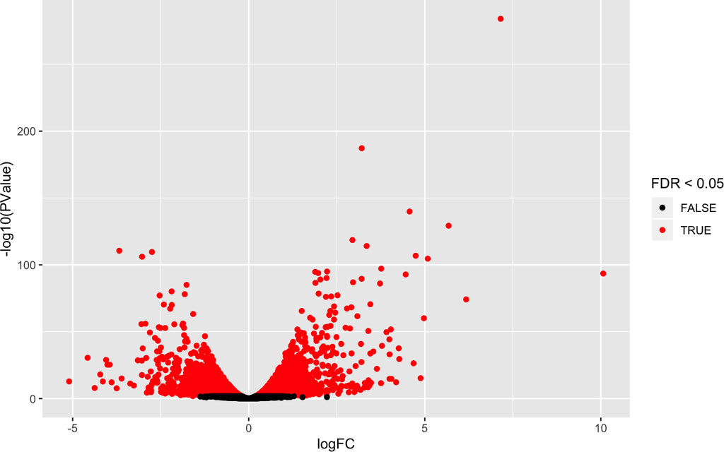

```r
library(ggplot2)
volcano<- ggplot(ttAll$table,aes(x=logFC,y=-log10(PValue),color=FDR<0.05)) + geom_point() + scale_color_manual(values=c("black","red"))
volcano
```

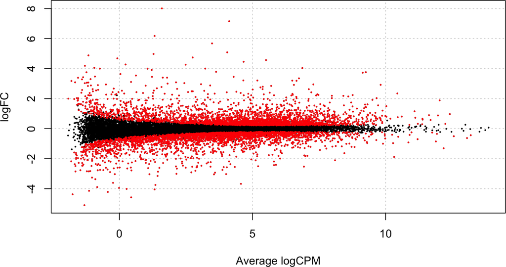

```r
plotSmear(lrt, de.tags = row.names(tt$table))
```

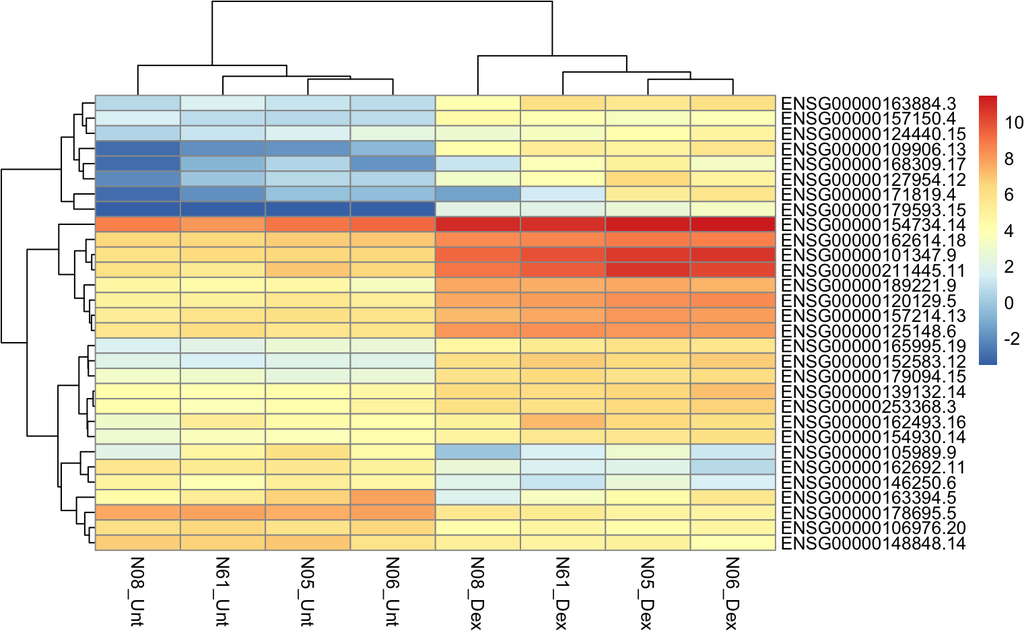

```r
library(pheatmap)
pheatmap(cpm(dge,log=TRUE)[rownames(tt$table)[1:30],])
```